# Problem Set 07

Your Name Here: Group X

Last updated: 2021-03-11

```r
# FIXME
library(tidyverse)
library(readxl)
library(cowplot)

library(knitr)
theme_set(theme_cowplot())
```

## Brook trout

You and a collaborator are studying the role of an introduced species (brook trout, *Salvelinus fontinalis*) on survival of native Chinook salmon (*Oncorhynchus tshawytscha*). Because you are located at different universities, you each have a different set of streams to sample. Independently, each of you measures survivorship of Chinook salmon in 15 streams that have introduced brook trout and in 15 streams that are free of brook trout. To estimate survivorship (percent alive), you released an equal number of tagged juvenile Chinook salmon into each stream and then resampled over the course of a year.

The two data files are:

1. Your data: `BrookTrout1.csv`
2. You collaborator’s data: `BrookTrout2.csv`

### Activity

Load each of the files into R.

```r
# FIXME
BT1 <- read_csv("../data/BrookTrout1.csv")
BT2 <- read_csv("../data/BrookTrout2.csv")
```

Make a plot of each data set using the same ggplot code you used to visualized the stalk-eyed fly data in the previous problem set. Plot the raw data (points) for the two groups (trout `Absent` and `Present`). For the points, include jitter and transparency. Include means and standard errors plotted in a different color.

Assign each plot to an R object (we like to use `p1` and `p2` for plot 1 and plot 2). Then use the `plot_grid()` function in the `cowplot` package to stack the two plots on top of one another. You code for the last step will look something like: `plot_grid(p1, p2, nrow = 2)`. If you used `ncol = 2` instead, you would get plots side by side.

`plot_grid()` is a really handy function for combining different ggplots into a single figure. It has facilities for adding labels (“a.”, “b.”, etc.), changing the spacing between plots, and much more. For us, it is indispensable for making publication-ready figures.

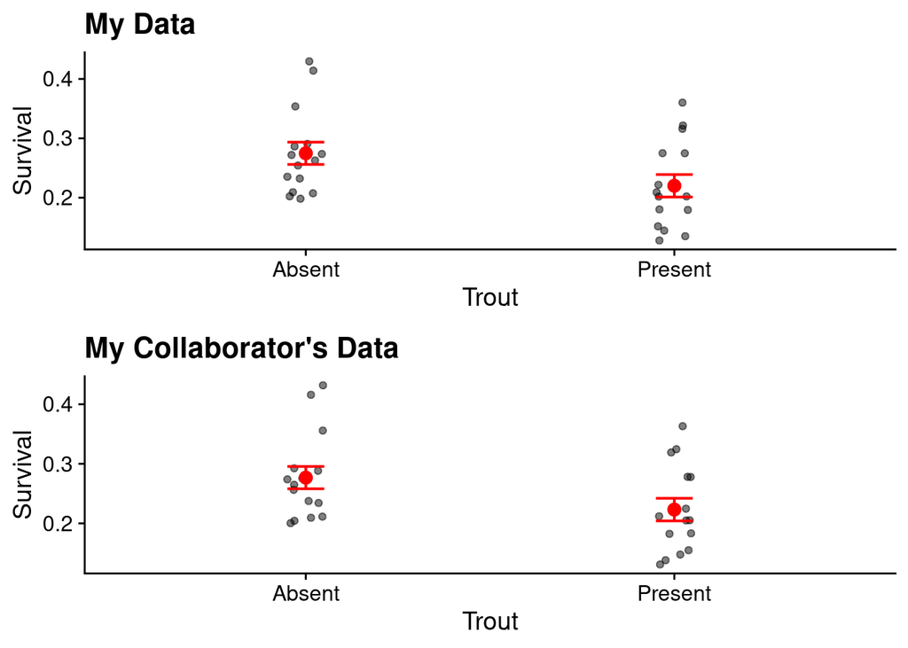

```r
# FIXME
p1 <- ggplot(BT1, aes(x = Trout, y = Proportion_Surviving)) +
  geom_point(position = position_jitter(width = 0.05), alpha = 0.5) +
  stat_summary(fun = mean, geom = "point", size = 3, color = "red") +
  stat_summary(fun.data = mean_se, geom = "errorbar", width = 0.1,
               color = "red", size = 0.7) +
  labs(x = "Trout", y = "Survival", title = "My Data")
p2 <- ggplot(BT2, aes(x = Trout, y = Proportion_Surviving)) +
  geom_point(position = position_jitter(width = 0.05), alpha = 0.5) +
  stat_summary(fun = mean, geom = "point", size = 3, color = "red") +
  stat_summary(fun.data = mean_se, geom = "errorbar", width = 0.1,
               color = "red", size = 0.7) +
  labs(x = "Trout", y = "Survival", title = "My Collaborator's Data")

plot_grid(p1, p2, nrow = 2)
```

Considering the plot you just made, do you think that mean survivorship is significantly different in the Absent/Present treatment groups? Do you think that the two sets of data are different from one another?

> There is much variability, but survival does appear to be higher in the trout absent treatment group. The SEMs don’t overlap it seems. There might be a significant different between treatments. The patterns look the same across locations.

First, fit a linear model to **your data** (from `BrookTrout1.csv`), in which the proportion of salmon surviving is modeled by presence or absence of trout. Print out the `summary()` of this linear model.

```r
# FIXME
fm1 <- lm(Proportion_Surviving ~ Trout, BT1)
summary(fm1)
```

```
##
## Call:
## lm(formula = Proportion_Surviving ~ Trout, data = BT1)
##
## Residuals:
##      Min       1Q   Median       3Q      Max
## -0.09220 -0.05978 -0.01497  0.04497  0.15493
##
## Coefficients:
##              Estimate Std. Error t value Pr(>|t|)
## (Intercept)   0.27480    0.01884  14.586 1.31e-14 ***
## TroutPresent -0.05470    0.02664  -2.053   0.0495 *
## ---
## Signif. codes:  0 '***' 0.001 '**' 0.01 '*' 0.05 '.' 0.1 ' ' 1
##
## Residual standard error: 0.07297 on 28 degrees of freedom
## Multiple R-squared:  0.1308, Adjusted R-squared:  0.09978
## F-statistic: 4.214 on 1 and 28 DF,  p-value: 0.04954
```

Note that, although these data are proportions (and thus bounded by 0 and 1), the observed values are normally distributed enough within in group to analyze with a regular linear model. If the values are clumped either close to 0 or to 1, then a different model is likely needed. For example, if you are trying to analyze student exam scores, you often run into problems because they are often heavily skewed and often run up against 1. Technically, it is the residuals that need to be normally distributed, but if the predictors are not normal then often the residuals won’t be either.

All that being said, how do you interpret the output of the linear model? Is there is significant difference in mean survival between the groups? Choose the $\alpha$-level you feel is appropriate.

> At $\alpha = 0.05$, there is a significant difference between the groups with lower salmon survivorship in the presence of trout (mean difference = 0.055 or 5.5%; P = 0.0495).

Now fit the same model to your **collaborator’s data** (from `BrookTrout2.csv`).

```r
# FIXME
fm2 <- lm(Proportion_Surviving ~ Trout, BT2)
summary(fm2)
```

```
##
## Call:
## lm(formula = Proportion_Surviving ~ Trout, data = BT2)
##
## Residuals:
##      Min       1Q   Median       3Q      Max
## -0.09220 -0.05978 -0.01497  0.04497  0.15493
##
## Coefficients:
##              Estimate Std. Error t value Pr(>|t|)
## (Intercept)   0.27680    0.01884  14.692  1.1e-14 ***
## TroutPresent -0.05370    0.02664  -2.015   0.0536 .
## ---
## Signif. codes:  0 '***' 0.001 '**' 0.01 '*' 0.05 '.' 0.1 ' ' 1
##
## Residual standard error: 0.07297 on 28 degrees of freedom
## Multiple R-squared:  0.1267, Adjusted R-squared:  0.09549
## F-statistic: 4.062 on 1 and 28 DF,  p-value: 0.05356
```

What do you conclude about your collaborator’s data?

> $P = 0.054$ here. So we conclude, based on $\alpha = 0.05$, that there is not a significant difference in means.

How do you feel about the results of these two studies?

> They are nearly identical (5.5% vs. 5.3% difference in survivorship), but the arbitrarily chosen $\alpha$ level leads you to two different conclusions.

Because you have data on individual-level survival of salmon, you might be tempted to use a [$\chi^2$ test of association](http://www.stat.yale.edu/Courses/1997-98/101/chisq.htm) on the combined data, which might look something like this table:

| Survival | Trout absent | Trout present |
| --- | --- | --- |
| Survived | 946 | 919 |
| Did not survive | 3470 | 3876 |

Why is this test not advisable in this case?

> The observations (whether an individual salmon juvenile was alive or not) are not independent of one another, streams add a level of structure to the data (all salmon in a stream are more likely to have the same survival probability). Later in the course, we will cover multilevel and logistic regression, which is another way to (correctly) model survival, accounting for possible different survival rates in both streams.

## Exact confidence intervals

We ultimately want to calculate exact confidence intervals for the proportion surviving in your data. First, we want to explore the adjustment for degrees of freedom (the critical *t*-value). Originally, we showed you how to calculate the approximate CI, using twice the standard error of the mean. Using 2 will result in too narrow CIs for small degrees of freedom and too wide CIs for large degrees of freedom.

### Activity

Make a plot of the critical value for a *t*-distribution for the 0.975 quantile (upper tail of 2.5%) where the degrees of freedom ranges from 2 to 100. First set up the vector of degrees of freedom (don’t call it df, because that is the name of an R function: the density of an *F*-distribution). Then calculate the critical values. Make a tibble and plot the results. Then add a differently colored horizontal line at the critical value for the 0.975 quantile for a standard normal distribution. Note that the critical value approaches the asymptotic limit as the degrees of freedom increases.

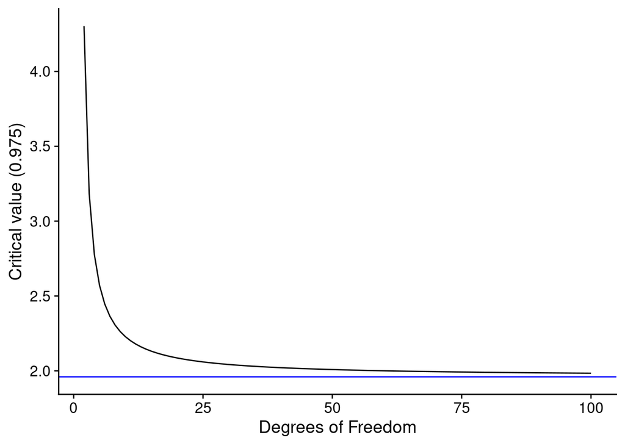

```r
# FIXME
CVs <- tibble(dfs = seq(2, 100, by = 1),
              crit_vals = qt(0.975, df = dfs,
                             lower.tail = TRUE))

CVs %>%
  ggplot(aes(dfs, crit_vals)) +
  geom_line() +
  geom_hline(yintercept = qnorm(0.025, lower.tail = FALSE),
             color = "blue") +
  labs(x = "Degrees of Freedom", y = "Critical value (0.975)")
```

Now calculate the exact 95% confidence intervals for the two groups in your data (from `BrookTrout1.csv`). Either pull the critical value from your tibble or just calculate anew.

```r
# Let's just adapt the approximate CI function from
# Problem Set 6. We will make it a little more flexible
# by allowing us to specify the desired interval with
# `prob`. Default to 95% CI.
SEM <- function(x) return(sd(x) / sqrt(length(x)))

exact_CI <- function(x, prob = 0.95) {
  t_crit <- qt((1 - prob) / 2,
               df = length(x) - 1,
               lower.tail = FALSE)
  Upper <- mean(x) + t_crit * SEM(x)
  Lower <- mean(x) - t_crit * SEM(x)
  return(tibble(Lower, Mean = mean(x), Upper))
}

CIs <- BT1 %>%
  group_by(Trout) %>%
  group_modify(~ exact_CI(.x$Proportion_Surviving))

knitr::kable(CIs)
```

| Trout | Lower | Mean | Upper |
| --- | --- | --- | --- |
| Absent | 0.2345760 | 0.2747997 | 0.3150235 |
| Present | 0.1795123 | 0.2201036 | 0.2606949 |

## Working with lists

Lists are one of the most flexible data structures in R. They can hold any combination of other types of R objects (including other lists). R functions like `lm()` return lists.[^1]

Lists are indexed a little differently from vectors and matrices. List indices are indexed using double brackets: `[[1]]` extracts (or assigns) the first element. Run the following code:

```r
mylist <- list()
mylist[[3]] <- 24
mylist
```

```
## [[1]]
## NULL
##
## [[2]]
## NULL
##
## [[3]]
## [1] 24
```

We first create an empty list, using the `list()` function. The second line assigns 24 to the 3rd element. When we print the list (last line), you can see that the 1st and 2nd elements are created and left as `NULL`. Managing lists can be harrowing:

```r
mylist[[1]] <- "hello world"
mylist[[2]] <- list(x = 12, y = "y", z = seq(1, 5, by = 0.2))
mylist
```

```
## [[1]]
## [1] "hello world"
##
## [[2]]
## [[2]]$x
## [1] 12
##
## [[2]]$y
## [1] "y"
##
## [[2]]$z
##  [1] 1.0 1.2 1.4 1.6 1.8 2.0 2.2 2.4 2.6 2.8 3.0 3.2 3.4 3.6 3.8 4.0 4.2 4.4 4.6
## [20] 4.8 5.0
##
##
## [[3]]
## [1] 24
```

Now the 1st element has a string, the 2nd has a list (which itself contains a numeric, a string, and a vector). How would you extract the 3rd element from the `z` vector?

```r
# FIXME
mylist[[2]]$z[3]
```

```
## [1] 1.4
```

We will use lists in a much less convoluted way, which is what you should do until you get comfortable (once you are comfortable with lists, their immense flexibility makes them a great way to pass collections of different kinds of data around among code).

For now, we will use a list to hold 4 plots, which we will arrange in a grid to make a usable figure.

### Activity

The file `mammals.xlsx` contains data for about 50 different traits. *All* 5416 species of mammals are included in the file, though none has data for all traits. We want to make some quick plots of four different traits plotted against body mass.

Rather than creating separate plots, we want to make them inside a loop, where we iterate through the columns of interest. This will make it easy to modify the format of the plots all at once, reducing the amount of code to keep up with. For example, change all the points to be transparent in one line rather than in four places.

1. Load the data from `mammals.xlsx`.
2. Create a column that holds the log10 transformation of `adult_body_mass_g` and one for the log10 of `basal_met_rate_m_l_o2hr`.
3. Create a vector of strings that we will use to iterate through the columns for analysis (we used `cols_analyze`). It should contain the following strings:
   - `ageat_eye_opening_d`
   - `log_BMR1 (or whatever you called the log10 of`basal_met_rate_m_l_o2hr`)
   - `gestation_len_d`
   - `litter_size`
4. Create a vector of strings to use for the y axis labels. Make sure that the order matches the order in your vector #3.
5. Create an empty list to hold plots: `pp <- list()` for example.

This is all we need for the setup. At this point, you have the data, two vectors (one of columns names and one of y axis labels), and an empty list.

```r
# FIXME
M <- read_excel("../data/mammals.xlsx", na = "NA") %>%
  mutate(log_Mass = log10(adult_body_mass_g),
         log_BMR = log10(basal_met_rate_m_l_o2hr))

cols_analyze <- c("ageat_eye_opening_d",
                  "log_BMR",
                  "gestation_len_d",
                  "litter_size")

axis_labels <- c("Age at Eye Opening",
                 "log10 BMR",
                 "Gestation Length",
                 "Litter Size")

pp <- list()
```

No we can work on a loop to iterate through the columns, making a plot for each column. Here is the pseudocode (https://blog.usejournal.com/how-to-write-pseudocode-a-beginners-guide-29956242698):

1. Create the framework for a `for` loop.
   - We want to iterate from 1 to `length(cols_analyze)`
2. Extract the *i*th element of the columns to analyze vector. Assign to an object.
3. Extract the *i*th element of the y axis label.
4. Make a bivariate plot of the column vs. log Body Mass (assign to an object). This will look a little different from ggplots you have made before, particularly the aesthetics. Because you are supplying raw strings, you need to use `aes_string`. It will look something like (`col` is the variable that holds the string with the column name):
   - `aes_string("log_Mass", col)`
5. Assign the plot to the *i*th element of your list.

```r
# FIXME
for (ii in 1:length(cols_analyze)) {
  col <- cols_analyze[ii]
  lab <- axis_labels[ii]
  p <- ggplot(M, aes_string("log_Mass", col)) +
    geom_point(alpha = 0.5, size = 0.5) +
    labs(x = "log10 Body Mass (g)", y = lab) +
    theme(axis.text = element_text(size = 10),
          axis.title = element_text(size = 10))
  pp[[ii]] <- p
}
```

At the end of the loop you will have a list that contains 4 plots. Try printing a plot by running `pp[[1]]` at the command line. If you get warnings saying something like `Removed 4948 rows containing missing values (geom_point).`, that is just ggplot saying that there are `NA`s in the data.

Now you can make a 2x2 grid of plots. The cowplot function `plot_grid()` can take a list of plots as an argument: `plotlist = ...`. Pass your list of plots, and specify 2 columns and 2 rows (check the help for `plot_grid()`).

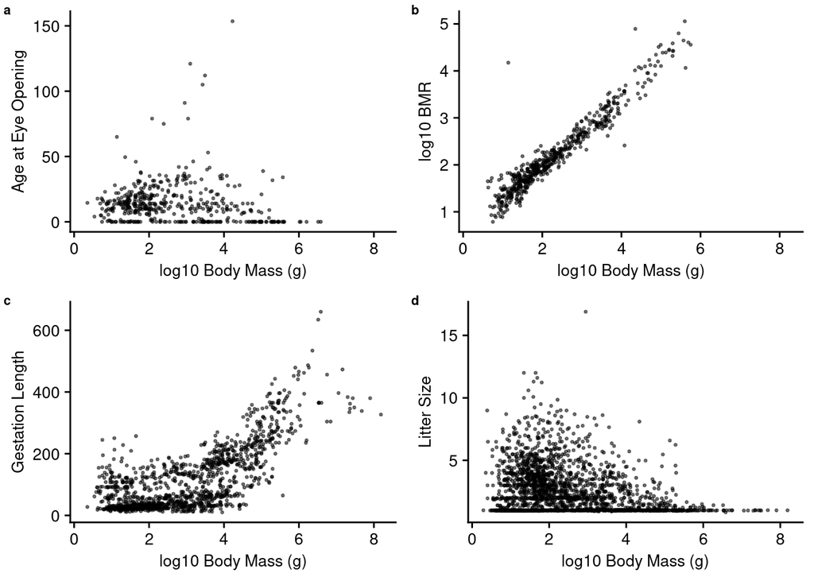

```r
# FIXME
plot_grid(plotlist = pp, ncol = 2, nrow = 2,
          labels = c("a", "b", "c", "d"),
          label_size = 8)
```

Now you can fine tune the plots:

- Add labels for x and y. The y label is the string you extracted from your vector of y axis labels.
- Make the points smaller (`size = 0.5`) and transparent
- Change the font size on the axis labels by adding the following code to your ggplot:

```
+ theme(axis.text = element_text(size = 10),
        axis.title = element_text(size = 10))
```

- Pass the argument `labels = c("a", "b", "c", "d")` to `plot_grid()` to add labels for each plot.

As you can see rather than sequentially editing 4 sets of code, trying to make sure they all stay in sync, we can just edit one plotting statement and change the data in each iteration.

[^1]: R functions can only return a single object (unlike languages like python and MATLAB, which can return multiple objects). So everything that needs to be returned from a function is placed into a list, which gets returned.